# Survival of C.elegans with three different media

Jonas Gehrlein

12 nov 2018

code for fitting Kaplan-Meier and log-rank test and for displaying survival curves for each type of media

|  | ï..Time | Status | Group | Replicate |
| --- | --- | --- | --- | --- |
| 1 | 4 | 1 | FG13 | 1 |
| 2 | 6 | 1 | FG13 | 1 |
| 3 | 6 | 1 | FG13 | 1 |
| 4 | 8 | 1 | FG13 | 1 |
| 5 | 8 | 1 | FG13 | 1 |
| 6 | 10 | 1 | FG13 | 1 |

here() should show that your position is in the folder 7.semester else select the active project to be 7.semester in the upper right corner.

Or make a new .Rproj file in the folder 7.semester. There is a problem with the numbers of the worms so we change that with col.names()

|  | Time | status | media | Replicate |
| --- | --- | --- | --- | --- |
| 1 | 4 | 1 | FG13 | 1 |
| 2 | 6 | 1 | FG13 | 1 |
| 3 | 6 | 1 | FG13 | 1 |
| 4 | 8 | 1 | FG13 | 1 |
| 5 | 8 | 1 | FG13 | 1 |
| 6 | 10 | 1 | FG13 | 1 |

Then we create a survival object with the survival package and make a kaplan-meier curve

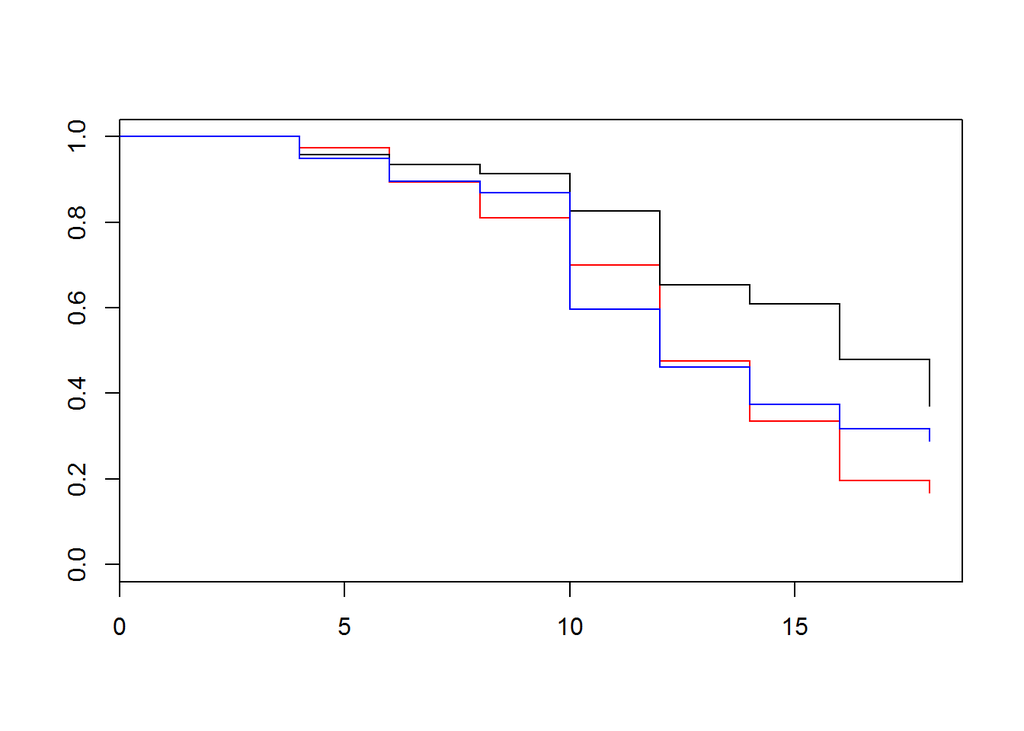

Shows errorbars and lineplot based on one of Anders papers https://onlinelibrary.wiley.com/doi/full/10.1111/acel.12165 This is done by extracting the surviving proportion, standard errors and time from survfit(). and adding a startpoint where the survival is 100% at 0 hours.

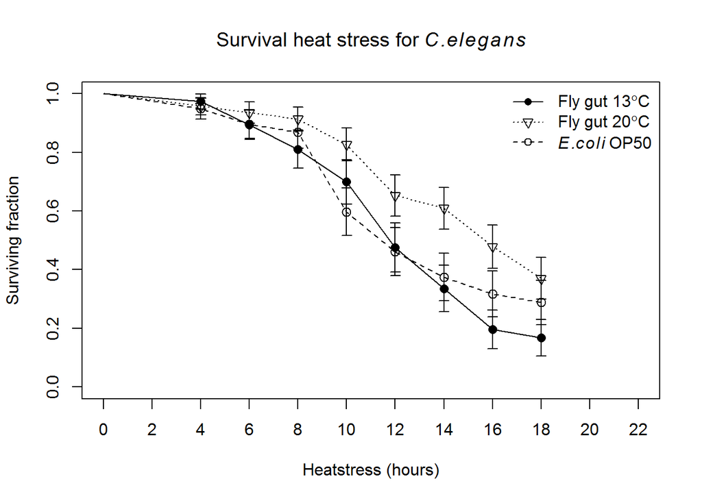

Then we create a normal Kaplan-Meier curve

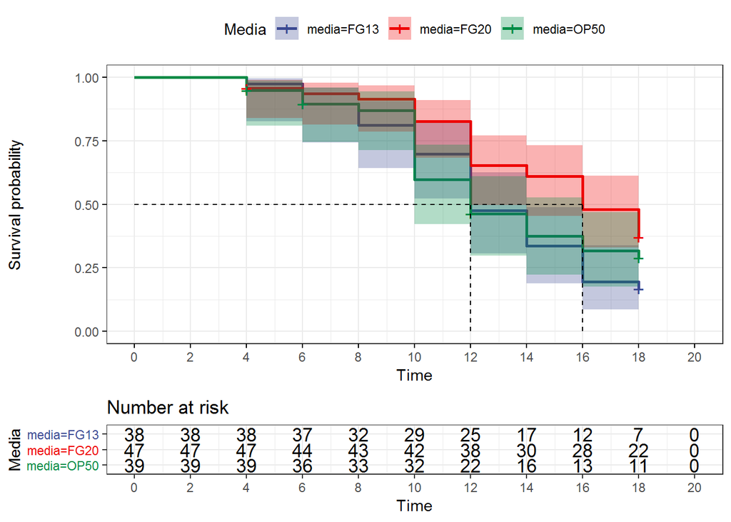

Now we test for difference between the curves with both log-rank and gehan-wilcoxon and with an cox proportional hazard model

```
## Call:
## survdiff(formula = Survobj ~ media, data = data, rho = 0)
##
##             N Observed Expected (O-E)^2/E (O-E)^2/V
## media=FG13 38       30     23.0     2.115     3.498
## media=FG20 47       29     38.4     2.280     5.052
## media=OP50 39       26     23.6     0.238     0.396
##
##  Chisq= 5.6  on 2 degrees of freedom, p= 0.06
```

```
## Call:
## survdiff(formula = Survobj ~ media, data = data, rho = 1)
##
##             N Observed Expected (O-E)^2/E (O-E)^2/V
## media=FG13 38     21.1     16.7     1.149      2.42
## media=FG20 47     18.6     26.0     2.101      5.80
## media=OP50 39     20.0     17.0     0.531      1.13
##
##  Chisq= 5.9  on 2 degrees of freedom, p= 0.05
```

```
## Call:
## coxph(formula = Survobj ~ media, data = data)
##
##   n= 124, number of events= 85
##
##              coef exp(coef) se(coef)      z Pr(>|z|)
## mediaFG20 -0.6010    0.5482   0.2622 -2.293   0.0219 *
## mediaOP50 -0.1943    0.8234   0.2685 -0.724   0.4693
## ---
## Signif. codes:  0 '***' 0.001 '**' 0.01 '*' 0.05 '.' 0.1 ' ' 1
##
##           exp(coef) exp(-coef) lower .95 upper .95
## mediaFG20    0.5482      1.824    0.3280    0.9165
## mediaOP50    0.8234      1.214    0.4865    1.3936
##
## Concordance= 0.576  (se = 0.037 )
## Rsquare= 0.044   (max possible= 0.997 )
## Likelihood ratio test= 5.57  on 2 df,   p=0.06
## Wald test            = 5.44  on 2 df,   p=0.07
## Score (logrank) test = 5.57  on 2 df,   p=0.06
```

We then try to split up in replicates to see if there are any differences between scorers

Then we make kaplan-meier curves and dose response curves

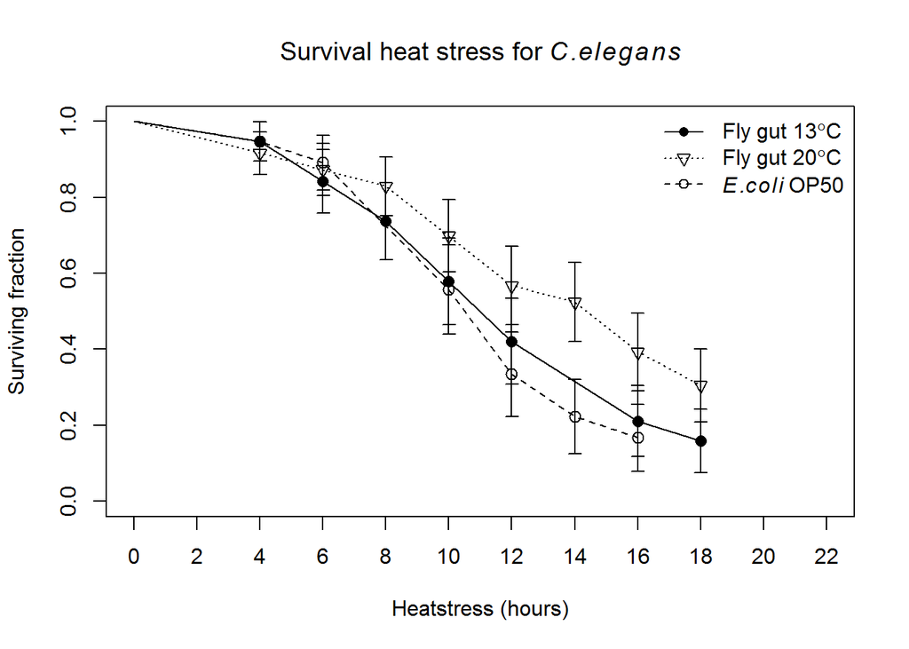

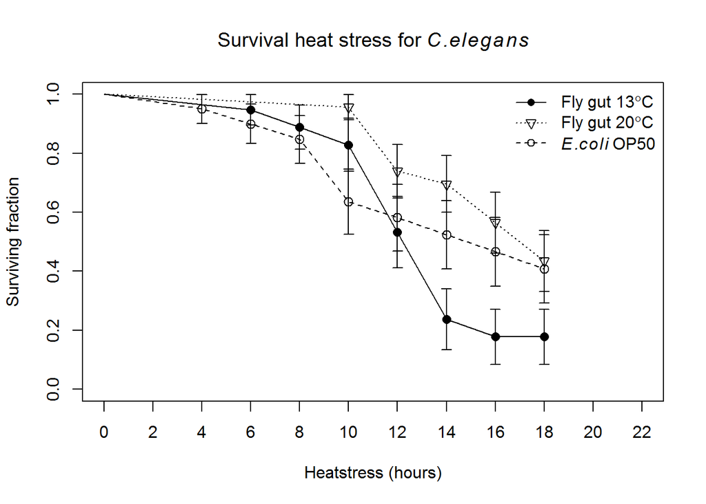

Then kaplan meier

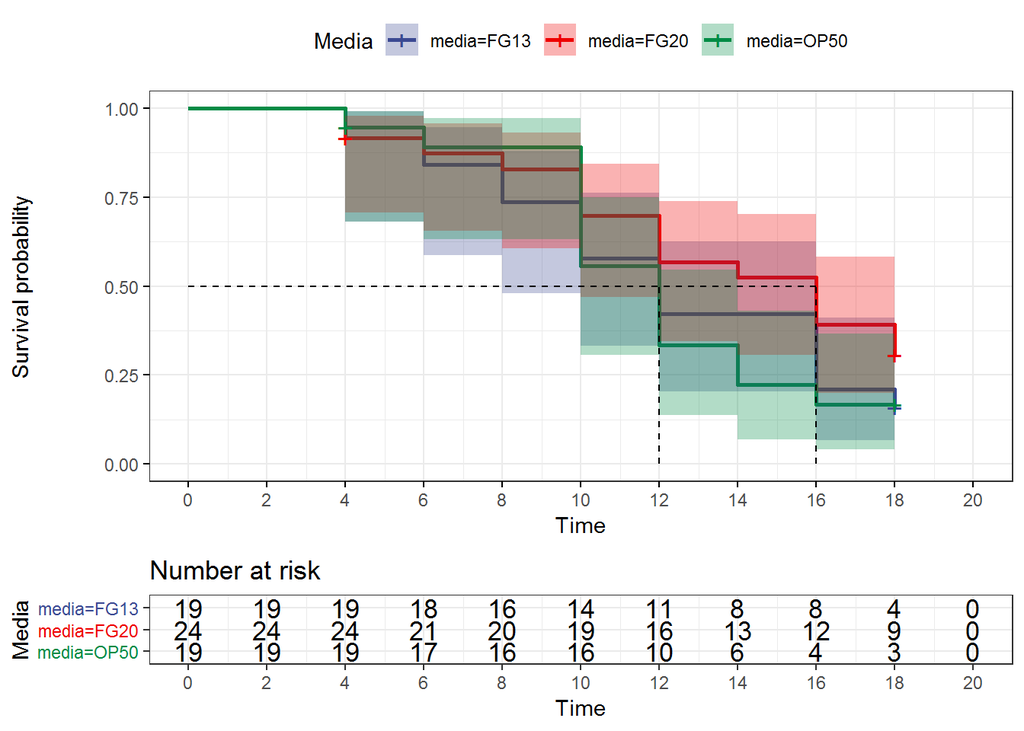

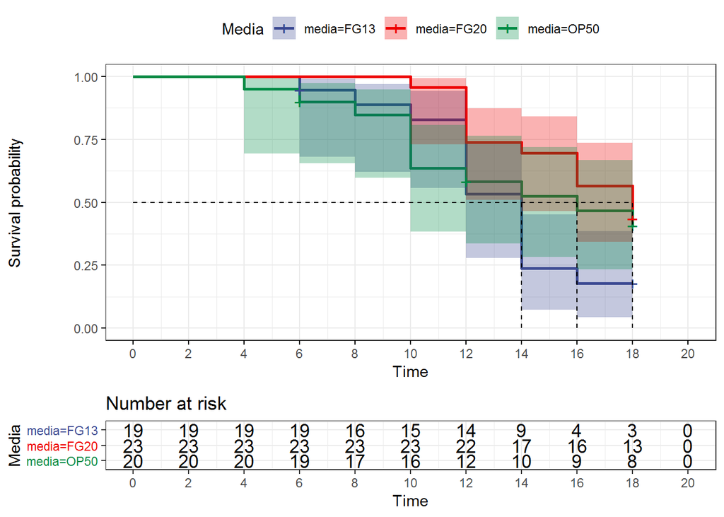

and at last some tests

```
## Call:
## survdiff(formula = Survobj ~ media, data = d1, rho = 0)
##
##             N Observed Expected (O-E)^2/E (O-E)^2/V
## media=FG13 19       16     14.1     0.244     0.431
## media=FG20 24       16     20.3     0.915     2.014
## media=OP50 19       15     12.5     0.480     0.815
##
##  Chisq= 2.1  on 2 degrees of freedom, p= 0.4
```

```
## Call:
## survdiff(formula = Survobj ~ media, data = d1, rho = 1)
##
##             N Observed Expected (O-E)^2/E (O-E)^2/V
## media=FG13 19     10.8     9.54     0.162     0.368
## media=FG20 24     10.3    13.14     0.613     1.687
## media=OP50 19     10.6     9.03     0.282     0.613
##
##  Chisq= 1.7  on 2 degrees of freedom, p= 0.4
```

```
## Call:
## coxph(formula = Survobj ~ media, data = d1)
##
##   n= 62, number of events= 47
##
##               coef exp(coef) se(coef)      z Pr(>|z|)
## mediaFG20 -0.41066   0.66321  0.35443 -1.159    0.247
## mediaOP50  0.07651   1.07951  0.36076  0.212    0.832
##
##           exp(coef) exp(-coef) lower .95 upper .95
## mediaFG20    0.6632     1.5078    0.3311     1.328
## mediaOP50    1.0795     0.9263    0.5323     2.189
##
## Concordance= 0.557  (se = 0.052 )
## Rsquare= 0.035   (max possible= 0.995 )
## Likelihood ratio test= 2.2  on 2 df,   p=0.3
## Wald test            = 2.13  on 2 df,   p=0.3
## Score (logrank) test = 2.16  on 2 df,   p=0.3
```

```
## Call:
## survdiff(formula = Survobj ~ media, data = d2, rho = 0)
##
##             N Observed Expected (O-E)^2/E (O-E)^2/V
## media=FG13 19       14     9.32  2.355719   3.72463
## media=FG20 23       13    17.77  1.282531   2.84312
## media=OP50 20       11    10.91  0.000743   0.00122
##
##  Chisq= 4.3  on 2 degrees of freedom, p= 0.1
```

```
## Call:
## survdiff(formula = Survobj ~ media, data = d2, rho = 1)
##
##             N Observed Expected (O-E)^2/E (O-E)^2/V
## media=FG13 19    10.58     7.27     1.510      2.95
## media=FG20 23     8.40    12.74     1.475      4.04
## media=OP50 20     8.98     7.96     0.131      0.27
##
##  Chisq= 4.6  on 2 degrees of freedom, p= 0.1
```

```
## Call:
## coxph(formula = Survobj ~ media, data = d2)
##
##   n= 62, number of events= 38
##
##              coef exp(coef) se(coef)      z Pr(>|z|)
## mediaFG20 -0.8083    0.4456   0.3905 -2.070   0.0385 *
## mediaOP50 -0.4944    0.6099   0.4073 -1.214   0.2248
## ---
## Signif. codes:  0 '***' 0.001 '**' 0.01 '*' 0.05 '.' 0.1 ' ' 1
##
##           exp(coef) exp(-coef) lower .95 upper .95
## mediaFG20    0.4456      2.244    0.2073     0.958
## mediaOP50    0.6099      1.639    0.2746     1.355
##
## Concordance= 0.603  (se = 0.053 )
## Rsquare= 0.066   (max possible= 0.989 )
## Likelihood ratio test= 4.23  on 2 df,   p=0.1
## Wald test            = 4.36  on 2 df,   p=0.1
## Score (logrank) test = 4.53  on 2 df,   p=0.1
```